# Проект Предсказание уровня удовлетворенности и вероятности увольнения сотрудника - git

1. Специалист отдела продаж или технического (ИТ) отдела
2. Больше всего начинающих специалистов на позиции junior
3. Имеет низкую или среднюю загруженность
4. Имеют более низкую зарплату, относительно неуволившихся сотрудников
5. В процентном соотношении количество уволившихся из всех департаментов примерно одинаковое

```python
df_megre = test_target_quit.merge(test_target_job_satisfaction_rate, how = 'left')
```

```python
%matplotlib inline
```

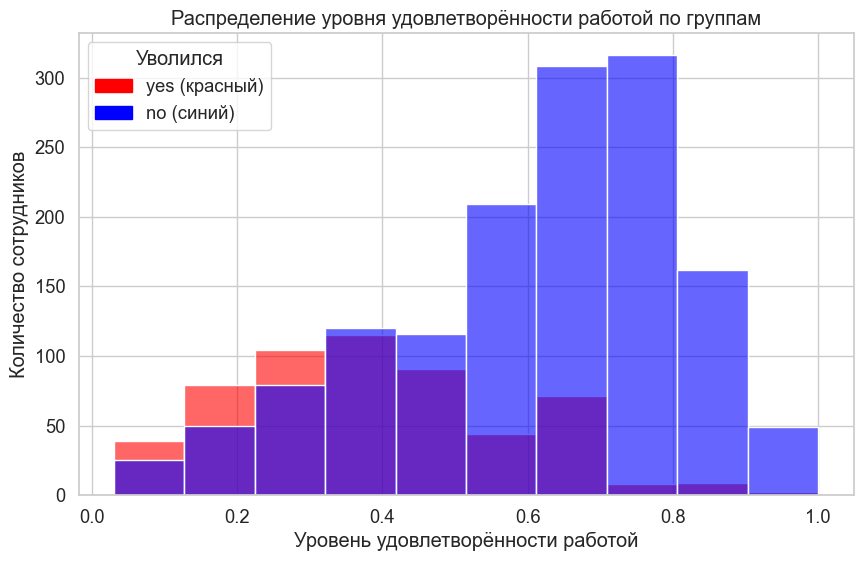

```python
# Построение графика
plt.figure(figsize=(10,6))
plot = sns.histplot(
    data=df_megre,
    x='job_satisfaction_rate',
    hue='quit',
    bins=10,
    kde=False,
    palette={'no': 'blue', 'yes': 'red'},  # Назначение цветов вручную
    alpha=0.6
)

# Добавление легенды вручную
from matplotlib.patches import Patch
legend_labels = [Patch(color='red', label='yes (красный)'),
                 Patch(color='blue', label='no (синий)')]

plt.legend(handles=legend_labels, title='Уволился')

# Добавление названий осей и заголовка
plt.title('Распределение уровня удовлетворённости работой по группам')
plt.xlabel('Уровень удовлетворённости работой')
plt.ylabel('Количество сотрудников')

# Показать график
plt.show()
```

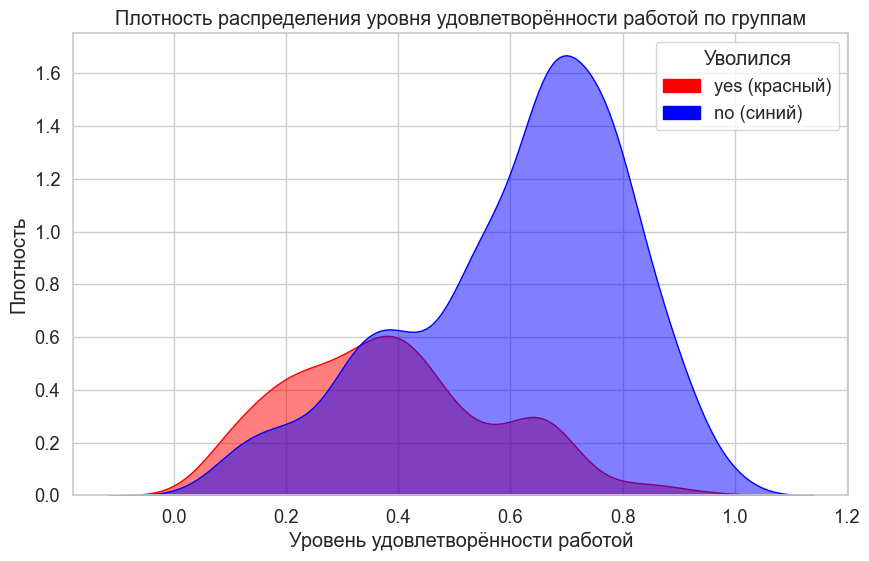

```python
# Построение графика плотности (KDE plot)
plt.figure(figsize=(10,6))
sns.kdeplot(
    data=df_megre,
    x='job_satisfaction_rate',
    hue='quit',
    fill=True,
    palette={'no': 'blue', 'yes': 'red'},  # Назначение цветов вручную
    alpha=0.5
)

# Создание объектов легенды вручную
legend_labels = [Patch(color='red', label='yes (красный)'),
                 Patch(color='blue', label='no (синий)')]

plt.legend(handles=legend_labels, title='Уволился')

# Добавление названий осей и заголовка
plt.title('Плотность распределения уровня удовлетворённости работой по группам')
plt.xlabel('Уровень удовлетворённости работой')
plt.ylabel('Плотность')

# Показать график
plt.show()
```

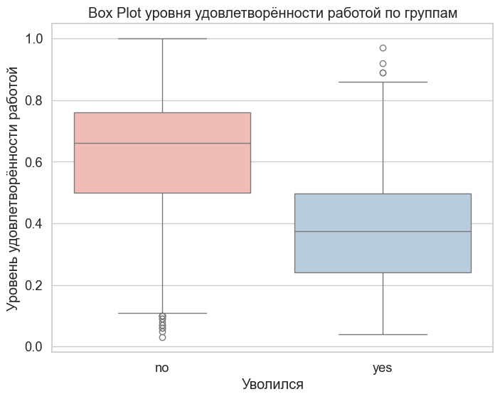

```python
plt.figure(figsize=(8,6))
sns.boxplot(data=df_megre, x='quit', y='job_satisfaction_rate', palette='Pastel1')
plt.title('Box Plot уровня удовлетворённости работой по группам')
plt.xlabel('Уволился')
plt.ylabel('Уровень удовлетворённости работой')
plt.show()
```

**Вывод:**

Результаты исследования поддерживает гипотезу о том, что уровень удовлетворённости работой может влиять на решение сотрудника уйти из компании.

## Добавление нового входного признака

```python
X_tr_job_satisfaction_rate = copy.deepcopy(train_quit.drop(['id','quit'], axis = 1))
```

```python
pred_job_satisfaction_rate = random_search.predict(X_tr_job_satisfaction_rate)
```

```python
X_tr_job_satisfaction_rate['pred_job_satisfaction_rate'] = pred_job_satisfaction_rate
```

**Готовим параметры X_train/y_train**

```python
X_train = X_tr_job_satisfaction_rate
```

```python
y_train = copy.deepcopy(train_quit['quit'])
```

**Готовим параметры X_test/y_test**

```python
X_ts_job_satisfaction_rate = copy.deepcopy(test_features.drop(['id'], axis = 1))
```

```python
pred_job_satisfaction_rate = random_search.predict(X_ts_job_satisfaction_rate)
X_ts_job_satisfaction_rate['pred_job_satisfaction_rate'] = pred_job_satisfaction_rate
```

```python
X_test = X_ts_job_satisfaction_rate
```

```python
y_test = test_target_quit['quit'].values
```

**Кодируем целевой параметр**

```python
label_encoder = LabelEncoder()
y_train_encoded = label_encoder.fit_transform(y_train)
y_test_encoded = label_encoder.transform(y_test)
```

```python
for i, class_name in enumerate(label_encoder.classes_):
    print(f'Категория: {class_name} -> Кодировка: {i}')
```

```
Категория: no -> Кодировка: 0
Категория: yes -> Кодировка: 1
```

```python
df_col = X_train.select_dtypes(include=np.number)
df_kach = X_train.select_dtypes(exclude=np.number)
```

```python
# создаём списки с названиями признаков
cat_columns = df_kach.columns
num_columns = df_col.columns
```